# (Prosper Loan Data-set Visualization)

## by (Merna Saleh)

# Investigation Overview

### We want to get answers for these questions?

# Dataset Overview

### Our data consists of 81 columns and there are a lot of missing values; so we had selected 12 features to visualize and find insights through it.

### The link: https://www.kaggle.com/justjun0321/prosperloandata

# Univariate Exploration

## What is the distribution of loan status?

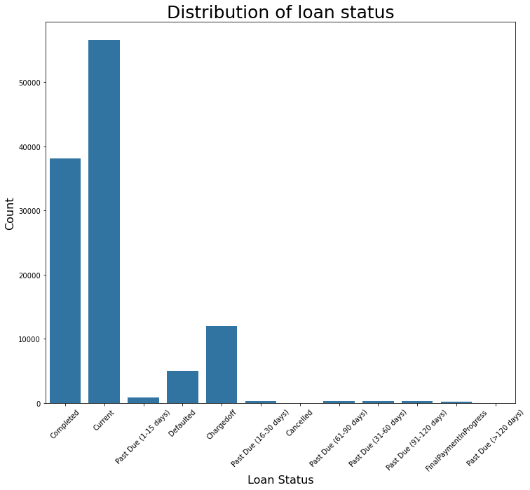

> We found most loans are among completed, current, Defaulted, and charged off; so we recommend making the categories of loan status in the previous categories to make it easier to be tracked and visualized.

## How many recommendations do the borrower have?

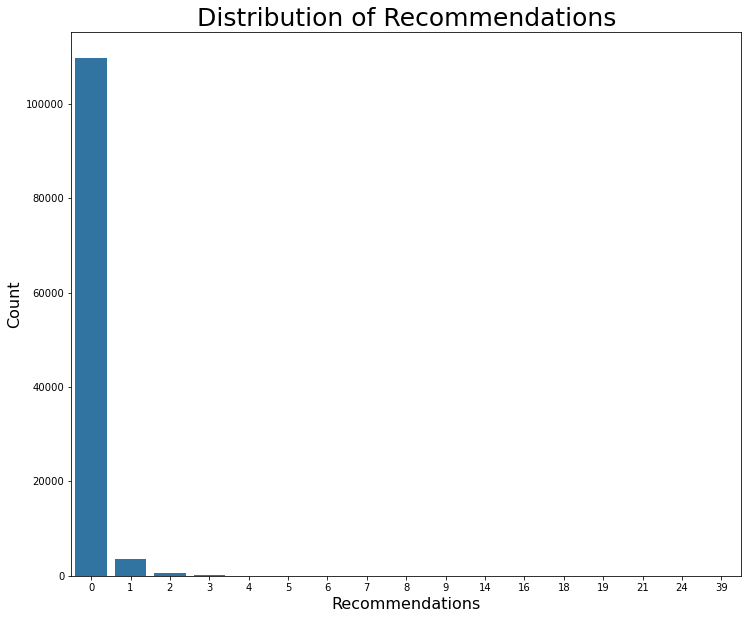

> It isn't necessary to have recommendations to borrow a loan.

## Is Borrower a home owner?

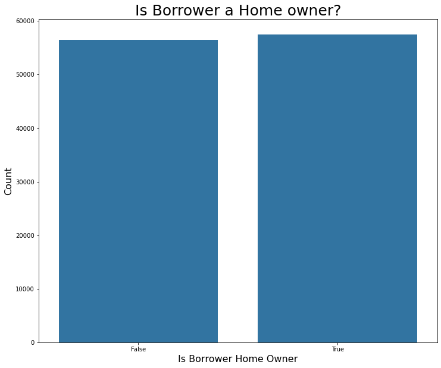

> The borrower of loan may have home or not; so the loan confirmation doesn't depend on if the borrower is a home owner or not.

## What is the ditribution of term?

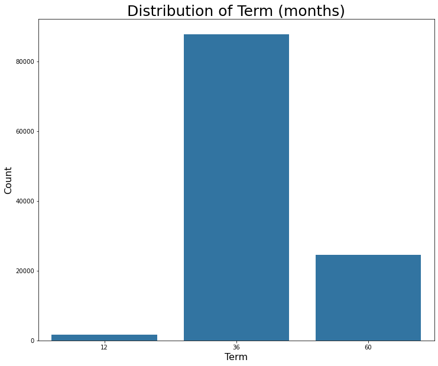

> Most of loans term length are 36 months.

## Are all borrowers currently in group?

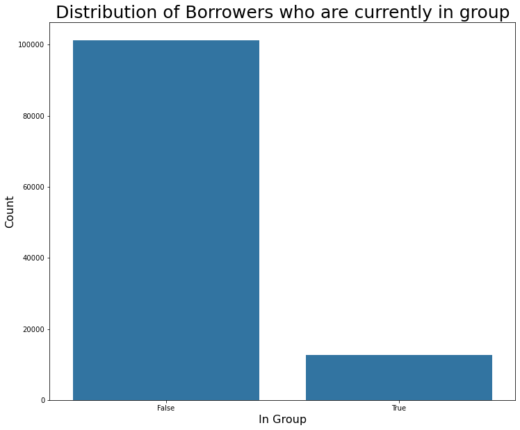

> Most of borrowers aren't in group in a group at the time the listing was created.

# Bivariate Exploration

## What is the relationship between the borrower rate and his/her income range?

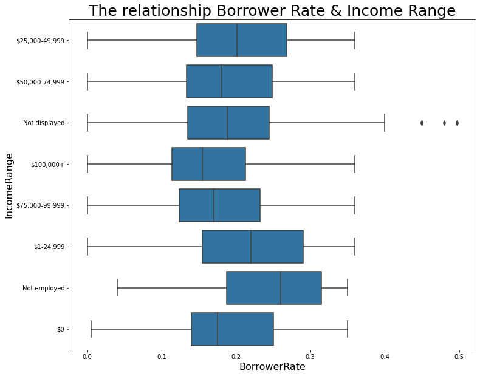

> If the borrowers are not employed, their borrowing rate are higher than the others.

## What is the relationship Loan Months Since Origination & Monthly Loan Payment?

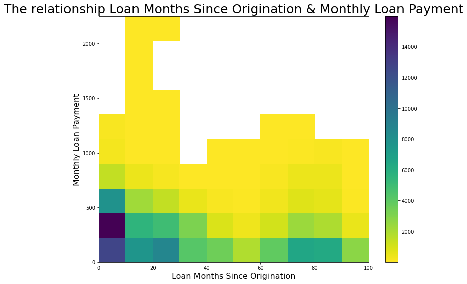

## What is the relationship between Investment From Friends Count & Investment From Friends Amount?

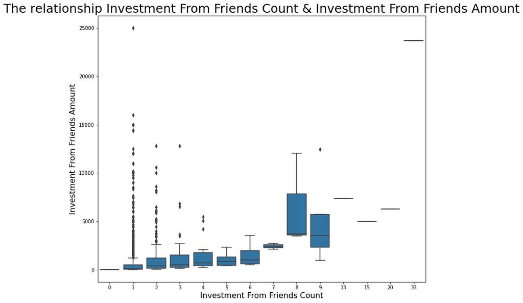

# Multivariate Exploration

## What is the relationship among LenderYield and Borrower APR vs ProsperRating?

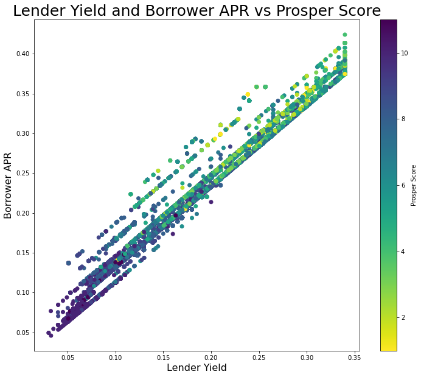

> This chart confirms the relations between BorrowerAPR and LenderYield, they have strong positive relationship (strong corrolation). Also, it shows that most of loans with lower BorrowerAPR & LenderYield have higher ProsperScore and visa-versa.

## What is the relationship among Borrower Rate and Estimated Loss vs Estimated Effective Yield?

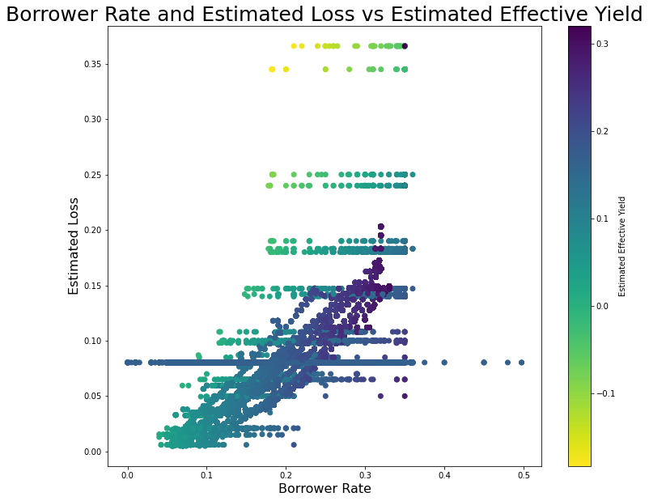

> This chart confirms the relations between Borrower Rate and Estimated Loss, they have positive relationship in most of points and have constant estimated loss at some samples.